```markdown
---
title: "Herb Leaf Analyzer Documentation"
author: "Sindayigaya Jean Marie Vianney"
date: "2024-04-15"
output: html_document
---
```

# Introduction

This document provides an overview and examples of how to use the **Herb Leaf Analyzer** package. Below is a list of functionalities provided by the package. For more details and updates, visit the [Herb Leaf Analyzer GitHub repository](https://github.com/JeanMarie3/HerbLeafAnalyzer).

## Package Functionalities

- **Load Herb Data**: Load data from `.RData` files containing detailed information about different herbs.
- **Analyze Leaf Color Distributions**: Visualize the distribution of colors found in herb leaves to understand their diversity.
- **Calculate Leaf Areas**: Compute the area of herb leaves, a critical measure in various botanical and ecological studies.
- **Compare Leaf Shapes**: Compare the geometrical shapes of leaves from different herb species to highlight their morphological differences.
- **Display Data in a Table**: Present herb data in a structured table format, allowing for easy visualization and comparison.

```r
# Loading functions
source("~/Documents/HerbLeafAnalyzer/R/HerbLeafAnalyzer.R")
```

```
##     species leaf_length leaf_width       color
## 1 Species A           5          3       Green
## 2 Species B           6          2  Dark green
## 3 Species C           7          4 Light green
```

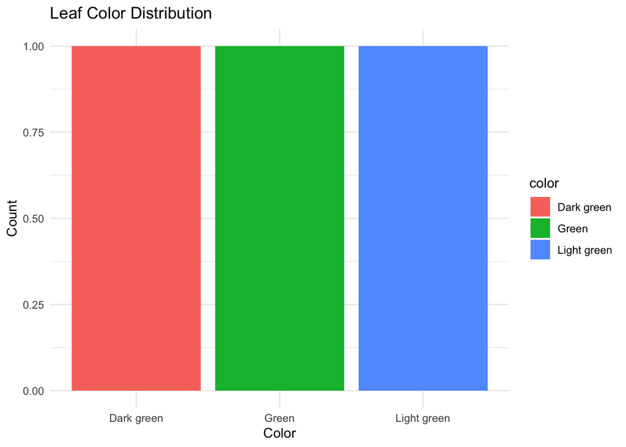

```
## [1] 21
```

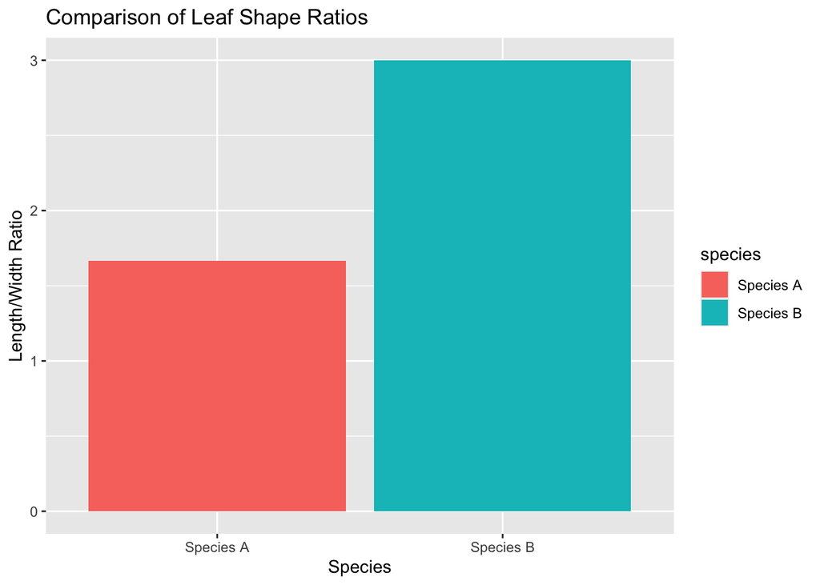

```
##     species leaf_length leaf_width       color
## 1 Species A           5          3       Green
## 2 Species B           6          2  Dark green
## 3 Species C           7          4 Light green
```

# Functions Documentation

## Load Herb Data

The `loadHerbData` function loads herb data from a specified `.RData` file.

```r
# Load the data
data <- loadHerbData("herbData.RData")
```

## Plot Leaf Color Distribution

The `plotLeafColorDistribution` function creates a bar plot showing the distribution of leaf colors.

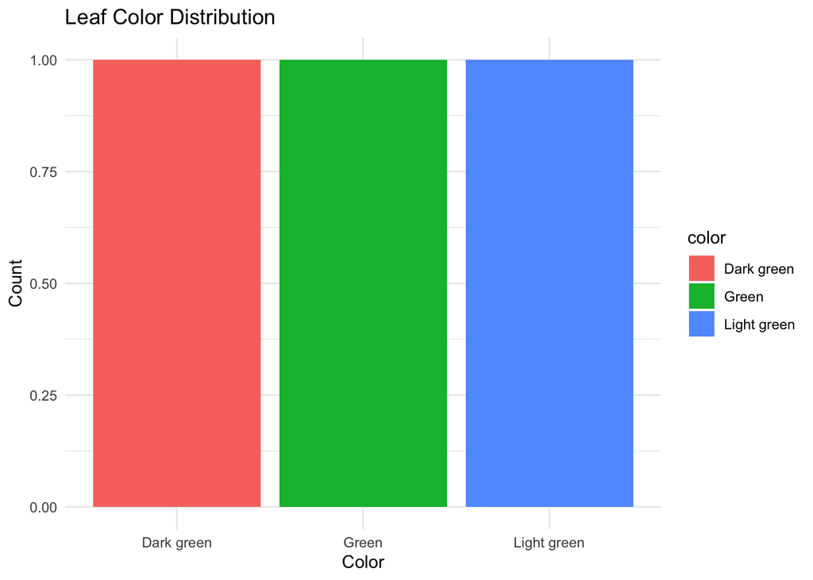

Leaf Color Distribution

```r
# Plotting leaf color distribution
plot <- plotLeafColorDistribution(data)
plot
```

## Calculate Leaf Area

The `calculateLeafArea` function calculates the area of a leaf based on provided length and width.

```r
# Calculating leaf area
area <- calculateLeafArea(7, 3)  # Example dimensions in cm
area
```

```
## [1] 21
```

## Compare Leaf Shape

The `compareLeafShape` function compares the shape of leaves from two specified species by plotting the ratio of leaf length to width.

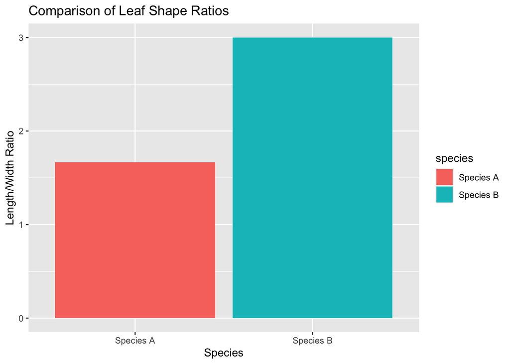

Comparison of Leaf Shape Ratios

```r
# Comparing leaf shapes
compare_plot <- compareLeafShape(data, "Species A", "Species B")
compare_plot
```

## Display Herb Table

The `displayHerbTable` function returns the provided data as a table.

```r
# Displaying data table
table <- displayHerbTable(data)
table
```

```
##     species leaf_length leaf_width       color
## 1 Species A           5          3       Green
## 2 Species B           6          2  Dark green
## 3 Species C           7          4 Light green
```